# Cancer Genomics Tutorial

SECTION 6

The input files for reading/summarizing MAF files are a MAF file (can be gz compressed), an optional clinical data associated with each sample, and an optional copy number data file. In this section, we read the MAF file and viewed the sample summary, the gene summary, the clinical data, and the fields.

```r
# 6.2: Reading MAF files
library(maftools)
clinical.data = read.table("tcga_laml_annot.tsv",sep
                           ="\t", header = TRUE) #read in metadata
laml = read.maf(maf = "tcga_laml.maf", clinicalData = clinical.data) #create a MAF object
relapse.apl = read.maf(maf = "APL_primary.maf")
APL_relapse.maf = read.maf(maf = "APL_relapse.maf")
brca = read.maf(maf = "brca.maf")

# 6.3: MAF Object
laml
getSampleSummary(laml)
getGeneSummary(laml)
getClinicalData(laml)
getFields(laml)
write.mafSummary(maf = laml, basename = 'laml')
```

[output not shown]

SECTION 7

In this section, we visualized the MAF data in various different ways. In 7.1, we first plotted the MAF summary: the number of variants in each sample is represented as a stacked bar plot and the variant types are represented by the box plot. Additionally, in 7.2, we drew oncoplots, or waterfall plots, which are a better representation of a maf file. In this oncoplot, we can see the frequency of mutations in the genes. We then classified SNPs into transitions and transversions in 7.3 using the titv function and ploted the summarized data as a boxplot showing overall distribution of six different conversions and as a stacked barplot showing fraction of conversions in each sample.

In 7.4, we created a lollipop plot in order to visualize the amino acid changes. This can be challenging because MAF files have no clear guidelines on naming the amino acid change field: the lolliplot function by default looks for the AAChange column, and if that is not found, it prints all available fields with a warning message. We then drew the general protein domains using plotProtein. In 7.5, we created rainfall plots. Because cancer genomes (especially solid tumors) are typically characterized by localized hyper-mutations, rainfall plots are especially useful. Rainfall plots can visualize hypermutated genomic regions by plotting inter-variant distance on a linear genomic scale. In section 7.6, we compared the mutation load against TCGA cohorts using tcgaCompare and plotted the results. Finally, we plotted the variant allele frequences (VAF) as a boxplot in order to estimate the clonal status of top mutated genes. Clonal genes typically have a mean allele frequency of around 50% (assuming pure samples).

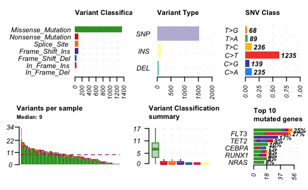

```r
# 7.1 Plotting MAF Summary
plotmafSummary(maf = laml, rmOutlier = TRUE, addStat = 'median', dashboard = TRUE, titvRaw = FALSE)
```

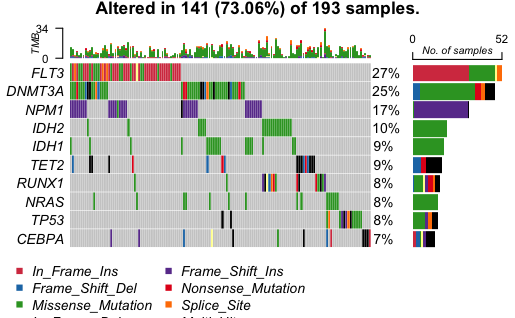

```r
# 7.2: Drawing oncoplots
oncoplot(maf = laml, top = 10)
```

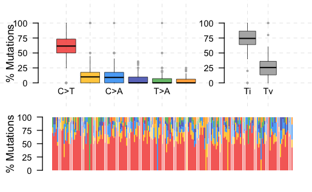

```r
# 7.3: Transition and Transversions
laml.titv = titv(maf = laml, plot = FALSE, useSyn = TRUE)
plotTiTv(res = laml.titv)
```

```
3 transcripts available. Use arguments refSeqID or proteinID to manually specify tx name.
```

| HGNC | refseq.ID | protein.ID | aa.length |
| --- | --- | --- | --- |
| DNMT3A | NM_022552 | NP_072046 | 912 |
| DNMT3A | NM_153759 | NP_715640 | 723 |
| DNMT3A | NM_175629 | NP_783328 | 912 |

```
Using longer transcript NM_022552 for now.
Removed 3 mutations for which AA position was not available
```

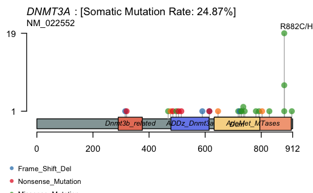

```r
# 7.4: Lolliplot plots for amino acid changes
lollipopPlot(
  maf = laml.maf,
  gene = 'DNMT3A',
  AACol = 'Protein_Change',
  showMutationRate = TRUE,
  labelPos = 882
)
```

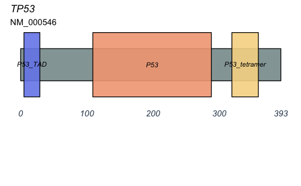

```r
plotProtein(gene = "TP53", refSeqID = "NM_000546")
```

```
Processing TCGA-A8-A08B..
Kataegis detected at:
```

| Chromosome | Start_Position | End_Position | nMuts | Avg_intermutation_dist | Size | Tumor_Sample_Barcode | C>G | C>T |
| --- | --- | --- | --- | --- | --- | --- | --- | --- |
| 8 | 98129348 | 98133560 | 7 | 702.0000 | 4212 | TCGA-A8-A08B | 4 | 3 |
| 8 | 98398549 | 98403536 | 9 | 623.3750 | 4987 | TCGA-A8-A08B | 1 | 8 |
| 8 | 98453076 | 98456466 | 9 | 423.7500 | 3390 | TCGA-A8-A08B | 1 | 8 |
| 8 | 124090377 | 124096810 | 22 | 306.3333 | 6433 | TCGA-A8-A08B | 1 | 21 |
| 12 | 97436055 | 97439705 | 7 | 608.3333 | 3650 | TCGA-A8-A08B | 4 | 3 |
| 17 | 29332072 | 29336153 | 8 | 583.0000 | 4081 | TCGA-A8-A08B | 4 | 4 |

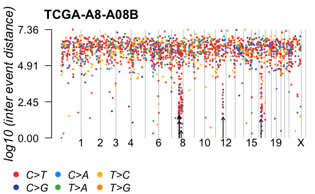

```r
# 7.5: Rainfall Plots
rainfallPlot(maf = brca, detectChangePoints = TRUE, pointSize = 0.4)
```

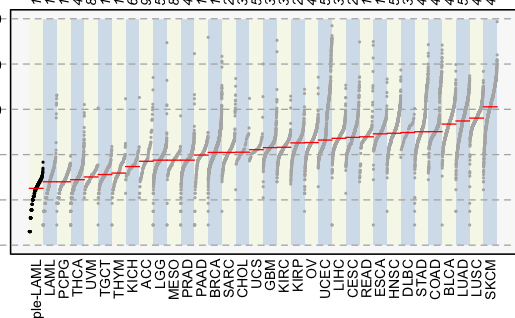

```r
# 7.6 Compare mutation load against TCGA cohorts
laml.mutload = tcgaCompare(maf = laml, cohortName = 'Example-LAML', logscale = TRUE, capture_size = 50)
# Plotting VAF
graphics.off()
par(mar=c(1,1,1,1))
```

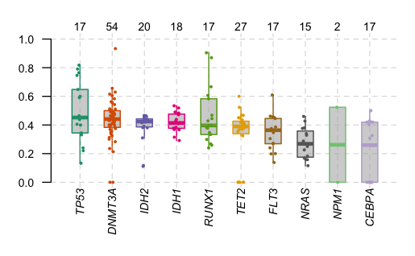

```r
plotVaf(maf = laml, vafCol = 'i_TumorVAF_WU')
```

SECTION 8

```r
# 8.1: Reading and summarizing gistic output files
all.lesions <- system.file("extdata", "all_lesions.conf_99.txt", package = "maftools")
amp.genes <- system.file("extdata", "amp_genes.conf_99.txt", package = "maftools")
del.genes <- system.file("extdata", "del_genes.conf_99.txt", package = "maftools")
scores.gis <- system.file("extdata", "scores.gistic", package = "maftools")

laml.gistic = readGistic(gisticAllLesionsFile = all.lesions, gisticAmpGenesFile = amp.genes, gisticDelGenesFile = del.genes, gisticScoresFile = scores.gis, isTCGA = TRUE)
```

```
-Processing Gistic files..
--Processing amp_genes.conf_99.txt
--Processing del_genes.conf_99.txt
--Processing scores.gistic
--Summarizing by samples
```

```r
laml.gistic
```

```
An object of class  GISTIC
```

| ID | summary |
| --- | --- |
| Samples | 191 |
| nGenes | 2622 |
| cytoBands | 16 |
| Amp | 388 |
| Del | 26481 |
| total | 26869 |

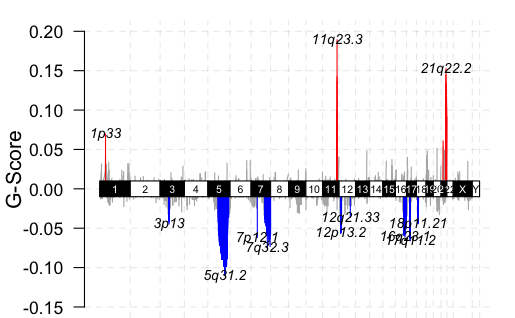

```r
# 8.2: Visualizing gistic results
# 8.2.1: Genome plot
gisticChromPlot(gistic = laml.gistic, markBands = "all")
```

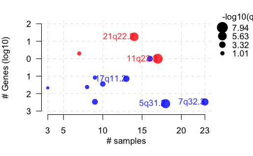

```r
# 8.2.2: Bubble plot
gisticBubblePlot(gistic = laml.gistic)
```

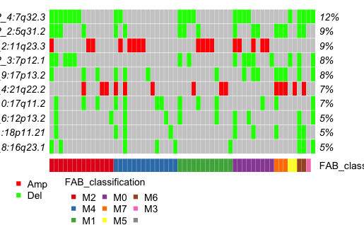

```r
#8.2.3: Oncoplot
gisticOncoPlot(gistic = laml.gistic, clinicalData = getClinicalData(x = laml.maf), clinicalFeatures = 'FAB_classification', sortByAnnotation = TRUE, top = 10)
```

SECTION 9

In section 9.6, we performed clinical enrichment analysis, which performs various groupwise/pairwise comparisons to identify enriched mutations for every category within a clinical feature (ie. FAB classification). In 9.7, we checked for drug-gene interactions and gene drugability information by pulling information compiled from the Drug Gene Interaction database. In section 9.8, we utilized the OncogenicPathways function to check for enrichment of known Oncogenic Signaling Pathway within TCGA cohorts.

| gene1 | gene2 | pValue | oddsRatio | 00 | 11 | 01 | 10 | Event | pair | event_ratio |
| --- | --- | --- | --- | --- | --- | --- | --- | --- | --- | --- |
| ASXL1 | RUNX1 | 0.0001541586 | 55.2155406 | 176 | 4 | 12 | 1 | Co_Occurence | ASXL1, RUNX1 | 4/13 |
| IDH2 | RUNX1 | 0.0002809928 | 9.5908774 | 164 | 7 | 9 | 13 | Co_Occurence | IDH2, RUNX1 | 7/22 |
| IDH2 | ASXL1 | 0.0004030636 | 41.0773269 | 172 | 4 | 1 | 16 | Co_Occurence | ASXL1, IDH2 | 4/17 |
| FLT3 | NPM1 | 0.0009929836 | 3.7631606 | 125 | 17 | 16 | 35 | Co_Occurence | FLT3, NPM1 | 17/51 |
| SMC3 | DNMT3A | 0.0010451985 | 20.1777127 | 144 | 6 | 42 | 1 | Co_Occurence | DNMT3A, SMC3 | 6/43 |
| DNMT3A | NPM1 | 0.0014582861 | 3.7331407 | 128 | 16 | 17 | 32 | Co_Occurence | DNMT3A, NPM1 | 16/49 |
| DNMT3A | IDH1 | 0.0033807043 | 4.4622015 | 137 | 10 | 8 | 38 | Co_Occurence | DNMT3A, IDH1 | 10/46 |
| ASXL1 | TTN | 0.0077607658 | 28.4594175 | 184 | 2 | 4 | 3 | Co_Occurence | ASXL1, TTN | 2/7 |
| PHF6 | RUNX1 | 0.0081059811 | 12.9670422 | 174 | 3 | 13 | 3 | Co_Occurence | PHF6, RUNX1 | 3/16 |
| TTN | RUNX1 | 0.0081059811 | 12.9670422 | 174 | 3 | 13 | 3 | Co_Occurence | RUNX1, TTN | 3/16 |

[output cut: 290 more lines]

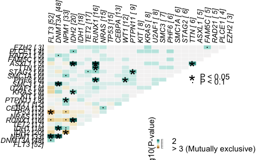

```r
# 9.1: Somatic Interactions
somaticInteractions(maf = laml, top = 25, pvalue = c(0.05, 0.1))
```

```r
# 9.2: Detecing cancer driver genes based on positional clustering
laml.sig = oncodrive(maf = laml, AACol = 'Protein_Change', minMut = 5, pvalMethod = 'zscore')
```

```
Comapring with background model and estimating p-values..
Done !
```

```r
head(laml.sig)
```

| Hugo_Symbol | Frame_Shift_Del | Frame_Shift_Ins | In_Frame_Del | In_Frame_Ins | Missense_Mutation | Nonsense_Mutation | Splice_Site | total | MutatedSamples | AlteredSamples | clusters | muts_in_clusters | clusterScores | protLen | zscore | pval | fdr | fract_muts_in_clusters |
| --- | --- | --- | --- | --- | --- | --- | --- | --- | --- | --- | --- | --- | --- | --- | --- | --- | --- | --- |
| IDH1 | 0 | 0 | 0 | 0 | 18 | 0 | 0 | 18 | 18 | 18 | 1 | 18 | 1.0000000 | 414 | 5.546154 | 1.460110e-08 | 1.022077e-07 | 1.0000000 |
| IDH2 | 0 | 0 | 0 | 0 | 20 | 0 | 0 | 20 | 20 | 20 | 2 | 20 | 1.0000000 | 452 | 5.546154 | 1.460110e-08 | 1.022077e-07 | 1.0000000 |
| NPM1 | 0 | 33 | 0 | 0 | 1 | 0 | 0 | 34 | 33 | 33 | 2 | 32 | 0.9411765 | 294 | 5.093665 | 1.756034e-07 | 8.194826e-07 | 0.9411765 |
| NRAS | 0 | 0 | 0 | 0 | 15 | 0 | 0 | 15 | 15 | 15 | 2 | 15 | 0.9218951 | 189 | 4.945347 | 3.800413e-07 | 1.330144e-06 | 1.0000000 |
| U2AF1 | 0 | 0 | 0 | 0 | 8 | 0 | 0 | 8 | 8 | 8 | 1 | 7 | 0.8750000 | 240 | 4.584615 | 2.274114e-06 | 6.367520e-06 | 0.8750000 |
| KIT | 1 | 1 | 0 | 1 | 7 | 0 | 0 | 10 | 8 | 8 | 2 | 9 | 0.8500000 | 976 | 4.392308 | 5.607691e-06 | 1.308461e-05 | 0.9000000 |

[figure not shown]

```r
plotOncodrive(res = laml.sig, fdrCutOff = 0.1, useFraction = TRUE, labelSize = 0.5)
```

[figure not shown]

```r
# 9.3: Adding and summarizing pfam domains
laml.pfam = pfamDomains(maf = laml, AACol = 'Protein_Change', top = 10)
```

```r
laml.pfam$proteinSummary[,1:7, with = FALSE]
```

| HGNC | AAPos | Variant_Classification | N | total | fraction | DomainLabel |
| --- | --- | --- | --- | --- | --- | --- |
| DNMT3A | 882 | Missense_Mutation | 27 | 54 | 0.50000000 | AdoMet_MTases |
| IDH1 | 132 | Missense_Mutation | 18 | 18 | 1.00000000 | PTZ00435 |
| IDH2 | 140 | Missense_Mutation | 17 | 20 | 0.85000000 | PTZ00435 |
| FLT3 | 835 | Missense_Mutation | 14 | 52 | 0.26923077 | PKc_like |
| FLT3 | 599 | In_Frame_Ins | 10 | 52 | 0.19230769 | PKc_like |
| U2AF1 | 34 | Missense_Mutation | 7 | 8 | 0.87500000 | zf-CCCH |
| NRAS | 61 | Missense_Mutation | 6 | 15 | 0.40000000 | H_N_K_Ras_like |
| KIT | 816 | Missense_Mutation | 5 | 10 | 0.50000000 | PTKc_Kit |
| NRAS | 13 | Missense_Mutation | 5 | 15 | 0.33333333 | H_N_K_Ras_like |
| FLT3 | 601 | In_Frame_Ins | 4 | 52 | 0.07692308 | PKc_like |

[output cut: 990 more lines]

```r
laml.pfam$domainSummary[,1:3, with = FALSE]
```

| DomainLabel | nMuts | nGenes |
| --- | --- | --- |
| PKc_like | 55 | 5 |
| PTZ00435 | 38 | 2 |
| AdoMet_MTases | 33 | 1 |
| 7tm_1 | 24 | 24 |
| COG5048 | 17 | 17 |
| Cadherin_repeat | 16 | 16 |
| Runt | 16 | 1 |
| Dcm | 15 | 1 |
| H_N_K_Ras_like | 15 | 1 |
| P53 | 15 | 2 |

[output cut: 493 more lines]

```
Looking for clinical data in annoatation slot of MAF..
Number of mutated samples for given genes:
```

```
DNMT3A
    48
```

```
Removed 11 samples with NA's
Median survival..
```

| Group | medianTime | N |
| --- | --- | --- |
| Mutant | 245 | 45 |
| WT | 396 | 137 |

[figure not shown]

```r
# 9.4: Survival analysis
# 9.4.1: Mutation in any given genes
mafSurvival(maf = laml, genes = 'DNMT3A', time = 'days_to_last_followup', Status = 'Overall_Survival_Status', isTCGA = TRUE)
```

```r
# 9.4.2: Predict genesets associated with survival
prog_geneset = survGroup(maf = laml, top = 20, geneSetSize = 2, time = "days_to_last_followup", Status = "Overall_Survival_Status", verbose = FALSE)
```

```
Removed 11 samples with NA's
```

```r
print(prog_geneset)
```

| Gene_combination | P_value | hr | WT | Mutant |
| --- | --- | --- | --- | --- |
| FLT3_DNMT3A | 0.00104 | 2.510 | 164 | 18 |
| DNMT3A_SMC3 | 0.04880 | 2.220 | 176 | 6 |
| DNMT3A_NPM1 | 0.07190 | 1.720 | 166 | 16 |
| DNMT3A_TET2 | 0.19600 | 1.780 | 176 | 6 |
| FLT3_TET2 | 0.20700 | 1.860 | 177 | 5 |
| NPM1_IDH1 | 0.21900 | 0.495 | 176 | 6 |
| DNMT3A_IDH1 | 0.29300 | 1.500 | 173 | 9 |
| IDH2_RUNX1 | 0.31800 | 1.580 | 176 | 6 |
| FLT3_NPM1 | 0.53600 | 1.210 | 165 | 17 |
| DNMT3A_IDH2 | 0.68000 | 0.747 | 178 | 4 |

[output cut: 1 more lines]

```
Looking for clinical data in annoatation slot of MAF..
Removed 11 samples with NA's
Median survival..
```

| Group | medianTime | N |
| --- | --- | --- |
| Mutant | 242.5 | 18 |
| WT | 379.5 | 164 |

[figure not shown]

```r
mafSurvGroup(maf = laml, geneSet = c("DNMT3A", "FLT3"), time = "days_to_last_followup", Status = "Overall_Survival_Status")
```

```r
# 9.5 Comparing two cohorts (MAFs)
#Primary APL MAF
primary.apl = system.file("extdata", "APL_primary.maf.gz", package = "maftools")
primary.apl = read.maf(maf = primary.apl)
```

```
-Reading
-Validating
--Non MAF specific values in Variant_Classification column:
  ITD
-Silent variants: 45
-Summarizing
-Processing clinical data
--Missing clinical data
-Finished in 0.103s elapsed (0.080s cpu)
```

```r
#Relapse APL MAF
relapse.apl = system.file("extdata", "APL_relapse.maf.gz", package = "maftools")
relapse.apl = read.maf(maf = relapse.apl)
```

```
-Reading
-Validating
--Non MAF specific values in Variant_Classification column:
  ITD
-Silent variants: 19
-Summarizing
-Processing clinical data
--Missing clinical data
-Finished in 0.087s elapsed (0.065s cpu)
```

```r
#Considering only genes which are mutated in at-least in 5 samples in one of the cohort to avoid bias due to genes mutated in single sample.
pt.vs.rt <- mafCompare(m1 = primary.apl, m2 = relapse.apl, m1Name = 'Primary', m2Name = 'Relapse', minMut = 5)
print(pt.vs.rt)
```

| Hugo_Symbol | Primary | Relapse | pval | or | ci.up | ci.low | adjPval |
| --- | --- | --- | --- | --- | --- | --- | --- |
| PML | 1 | 11 | 1.529935e-05 | 0.03537381 | 0.2552937 | 0.000806034 | 0.0001376942 |
| RARA | 0 | 7 | 2.574810e-04 | 0.00000000 | 0.3006159 | 0.000000000 | 0.0011586643 |
| RUNX1 | 1 | 5 | 1.310500e-02 | 0.08740567 | 0.8076265 | 0.001813280 | 0.0393149868 |
| FLT3 | 26 | 4 | 1.812779e-02 | 3.56086275 | 14.7701728 | 1.149009169 | 0.0407875250 |
| ARID1B | 5 | 8 | 2.758396e-02 | 0.26480490 | 0.9698686 | 0.064804160 | 0.0496511201 |
| WT1 | 20 | 14 | 2.229087e-01 | 0.60619329 | 1.4223101 | 0.263440988 | 0.3343630535 |
| KRAS | 6 | 1 | 4.334067e-01 | 2.88486293 | 135.5393108 | 0.337679367 | 0.4897762916 |
| NRAS | 15 | 4 | 4.353567e-01 | 1.85209500 | 8.0373994 | 0.553883512 | 0.4897762916 |
| ARID1A | 7 | 4 | 7.457274e-01 | 0.80869223 | 3.9297309 | 0.195710173 | 0.7457273717 |

| Cohort | SampleSize |
| --- | --- |
| Primary | 124 |
| Relapse | 58 |

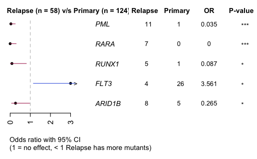

```r
# 9.5.1: Forest plots
forestPlot(mafCompareRes = pt.vs.rt, pVal = 0.1)
```

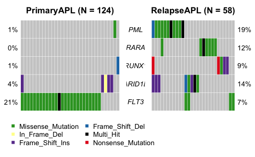

```r
# 9.5.2: Co-onco plots
genes = c("PML", "RARA", "RUNX1", "ARID1B", "FLT3")
coOncoplot(m1 = primary.apl, m2 = relapse.apl, m1Name = 'PrimaryAPL', m2Name = 'RelapseAPL', genes = genes, removeNonMutated = TRUE)
```

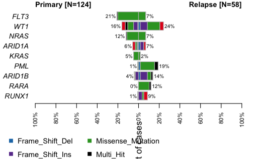

```r
# 9.5.3: Co-bar plots
coBarplot(m1 = primary.apl, m2 = relapse.apl, m1Name = "Primary", m2Name = "Relapse")
```

```
Gene: PML
9 transcripts available. Use arguments refSeqID or proteinID to manually specify tx name.
```

| HGNC | refseq.ID | protein.ID | aa.length |
| --- | --- | --- | --- |
| PML | NM_002675 | NP_002666 | 633 |
| PML | NM_033238 | NP_150241 | 882 |
| PML | NM_033239 | NP_150242 | 829 |
| PML | NM_033240 | NP_150243 | 611 |
| PML | NM_033244 | NP_150247 | 560 |
| PML | NM_033246 | NP_150249 | 423 |
| PML | NM_033247 | NP_150250 | 435 |
| PML | NM_033249 | NP_150252 | 585 |
| PML | NM_033250 | NP_150253 | 781 |

```
Using longer transcript NM_033238 for now.
9 transcripts available. Use arguments refSeqID or proteinID to manually specify tx name.
```

| HGNC | refseq.ID | protein.ID | aa.length |
| --- | --- | --- | --- |
| PML | NM_002675 | NP_002666 | 633 |
| PML | NM_033238 | NP_150241 | 882 |
| PML | NM_033239 | NP_150242 | 829 |
| PML | NM_033240 | NP_150243 | 611 |
| PML | NM_033244 | NP_150247 | 560 |
| PML | NM_033246 | NP_150249 | 423 |
| PML | NM_033247 | NP_150250 | 435 |
| PML | NM_033249 | NP_150252 | 585 |
| PML | NM_033250 | NP_150253 | 781 |

```
Using longer transcript NM_033238 for now.
```

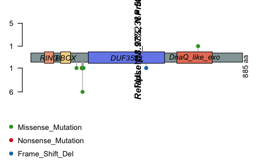

```r
# 9.5.4 Lollipop plot-2
lollipopPlot2(m1 = primary.apl, m2 = relapse.apl, gene = "PML", AACol1 = "amino_acid_change", AACol2 = "amino_acid_change", m1_name = "Primary", m2_name = "Relapse")
```

```r
# 9.6: Clinical enrichment analysis
fab.ce = clinicalEnrichment(maf = laml, clinicalFeature = 'FAB_classification')
```

```
Sample size per factor in FAB_classification:
```

```
M0 M1 M2 M3 M4 M5 M6 M7
19 44 44 21 39 19  3  3
```

```r
fab.ce$groupwise_comparision[p_value < 0.05]
```

| Hugo_Symbol | Group1 | Group2 | n_mutated_group1 | n_mutated_group2 | p_value | OR | OR_low | OR_high | fdr |
| --- | --- | --- | --- | --- | --- | --- | --- | --- | --- |
| IDH1 | M1 | Rest | 11 of 44 | 7 of 149 | 0.0002597371 | 6.670592 | 2.173829026 | 21.9607250 | 0.0308575 |
| TP53 | M7 | Rest | 3 of 3 | 12 of 190 | 0.0003857187 | Inf | 5.355415451 | Inf | 0.0308575 |
| DNMT3A | M5 | Rest | 10 of 19 | 38 of 174 | 0.0089427384 | 3.941207 | 1.333635173 | 11.8455979 | 0.3757978 |
| CEBPA | M2 | Rest | 7 of 44 | 6 of 149 | 0.0117352110 | 4.463237 | 1.204699322 | 17.1341278 | 0.3757978 |
| RUNX1 | M0 | Rest | 5 of 19 | 11 of 174 | 0.0117436825 | 5.216902 | 1.243812880 | 19.4051505 | 0.3757978 |
| NPM1 | M5 | Rest | 7 of 19 | 26 of 174 | 0.0248582372 | 3.293201 | 1.001404899 | 10.1210509 | 0.5880102 |
| NPM1 | M3 | Rest | 0 of 21 | 33 of 172 | 0.0278630823 | 0.000000 | 0.000000000 | 0.8651972 | 0.5880102 |
| DNMT3A | M3 | Rest | 1 of 21 | 47 of 172 | 0.0294005111 | 0.133827 | 0.003146708 | 0.8848897 | 0.5880102 |

[figure not shown]

```r
plotEnrichmentResults(enrich_res = fab.ce, pVal = 0.05, geneFontSize = 0.5, annoFontSize = 0.6)
# 9.7: Drug-Gene Interactions
dgi = drugInteractions(maf = laml, fontSize = 0.75)
```

```r
dnmt3a.dgi = drugInteractions(genes = "DNMT3A", drugs = TRUE)
```

```
Number of claimed drugs for given genes:
```

| Gene | N |
| --- | --- |
| DNMT3A | 7 |

```r
dnmt3a.dgi[,.(Gene, interaction_types, drug_name, drug_claim_name)]
```

| Gene | interaction_types | drug_name | drug_claim_name |
| --- | --- | --- | --- |
| DNMT3A |  |  | N/A |
| DNMT3A |  | DAUNORUBICIN | Daunorubicin |
| DNMT3A |  | DECITABINE | Decitabine |
| DNMT3A |  | IDARUBICIN | IDARUBICIN |
| DNMT3A |  | DECITABINE | DECITABINE |
| DNMT3A | inhibitor | DECITABINE | CHEMBL1201129 |
| DNMT3A | inhibitor | AZACITIDINE | CHEMBL1489 |

| Pathway | N | n_affected_genes | fraction_affected | Mutated_samples | Fraction_mutated_samples |
| --- | --- | --- | --- | --- | --- |
| PI3K | 29 | 1 | 0.03448276 | 1 | 0.005181347 |
| NRF2 | 3 | 1 | 0.33333333 | 1 | 0.005181347 |
| TP53 | 6 | 2 | 0.33333333 | 15 | 0.077720207 |
| WNT | 68 | 3 | 0.04411765 | 4 | 0.020725389 |
| MYC | 13 | 3 | 0.23076923 | 3 | 0.015544041 |
| NOTCH | 71 | 6 | 0.08450704 | 8 | 0.041450777 |
| Hippo | 38 | 7 | 0.18421053 | 7 | 0.036269430 |
| RTK-RAS | 85 | 18 | 0.21176471 | 97 | 0.502590674 |

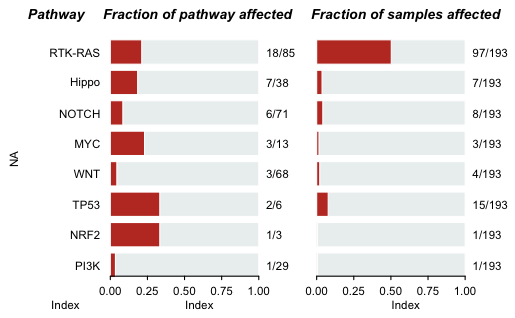

```r
# 9.8: Oncogenic Signaling Pathways
OncogenicPathways(maf = laml)
```

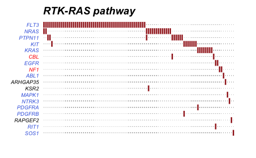

```r
PlotOncogenicPathways(maf = laml, pathways = "RTK-RAS")
```